# Model Selection – Part 1 (Notes)

Stat 253

Author

## Notes: Inferential v. Predictive Models

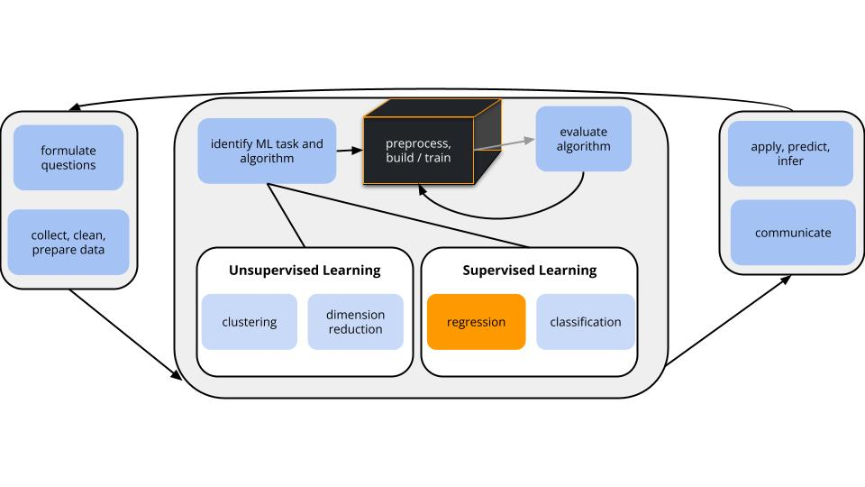

**CONTEXT**

- **world = supervised learning**  
  We want to model some output variable $y$ using a set of *potential* predictors ($x_1, x_2, ..., x_p$).
- **task = regression**  
  $y$ is quantitative
- **model = linear regression**  
  We’ll assume that the relationship between $y$ and ($x_1, x_2, ..., x_p$) can be represented by

  $$y = \beta_0 + \beta_1 x_1 + \beta_2 x_2 + ... + \beta_p x_p + \varepsilon$$

**Inferential v. Predictive Models (Unit 2 motivation)**

In model building, the decision of which predictors to use depends upon our goal.

**Inferential models**

- Goal: Explore & test hypotheses about a specific relationship.
- Predictors: Defined by the goal.
- Example: An economist wants to understand how salaries ($y$) vary by age ($x_1$) while controlling for education level ($x_2$).

**Predictive models**

- Goal: Produce the “best” possible predictions of $y$.
- Predictors: Any combination of predictors that help us meet this goal.
- Example: A mapping app wants to provide users with quality estimates of arrival time ($y$) utilizing any useful predictors (eg: time of day, distance, route, speed limit, weather, day of week, traffic radar…)

**UNIT 2 GOAL**

**Model selection** algorithms can *help* us build a **predictive model** of $y$ using a set of potential predictors ($x_1, x_2, ..., x_p$). There are 3 general approaches to this task:

1. **Variable selection (today)**  
   Identify a *subset* of predictors to use in our model of $y$.
2. **Shrinkage / regularization (next class)**  
   *Shrink* / regularize the coefficients of all predictors toward or to 0.
3. **Dimension reduction (later in the semester)**  
   *Combine* the predictors into a smaller set of new predictors.

## Exercises

Let’s build a **predictive model** of `height` in inches using one or more of 12 possible predictors. Other than `age` and `weight`, these are circumferences measured in cm.

```r
# Load packages
library(tidyverse)
library(tidymodels)

# Load data
humans <- read.csv("https://kegrinde.github.io/stat253_coursenotes/data/bodyfat1.csv")
names(humans)
##  [1] "age"     "weight"  "neck"    "chest"   "abdomen" "hip"     "thigh"
##  [8] "knee"    "ankle"   "biceps"  "forearm" "wrist"   "height"
```

A **heat map** displays correlations for each pair of variables in our dataset. Not only is `height` correlated with multiple predictors, the predictors are correlated with one another (mulicollinear)! We don’t need *all* of them in our model.

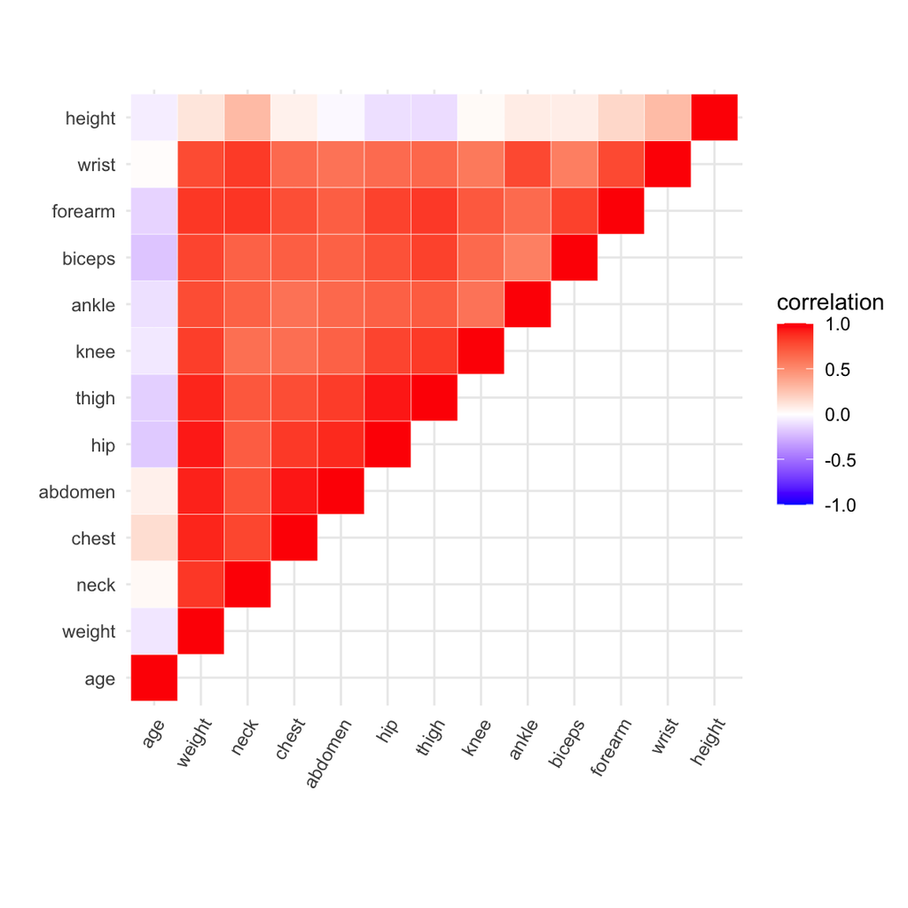

```r
# Get the correlation matrix
library(reshape2)
cor_matrix <- cor(humans)
cor_matrix[lower.tri(cor_matrix)] <- NA
cor_matrix <- cor_matrix %>%
  melt() %>%
  na.omit() %>%
  rename(correlation = value)

# Visualize the correlation for each pair of variables
ggplot(cor_matrix, aes(x = Var1, y = Var2, fill = correlation)) +
  geom_tile(color = "white") +
  scale_fill_gradient2(
    low = "blue", high = "red", mid = "white",
    midpoint = 0, limit = c(-1,1)) +
  labs(x = "", y = "") +
  theme_minimal() +
  theme(axis.text.x = element_text(angle = 60, hjust = 1)) +
  coord_fixed()
```

*As a group*, you’ll design a **variable selection algorithm** to pick which of the 12 predictors to use in a predictive model of `height`.

This will NOT be perfect!

The goal is to:

- Have fun and work together!
- Tap into your *intuition* for key questions and challenges in variable selection.
- *Deepen* your understanding of “algorithms” and “tuning parameters” by designing and communicating your own.

## Exercise 1: Design your own algorithm (15 minutes)

- Do not use any materials from outside this class.
- Document your algorithm in words (not code) in this [google doc](https://docs.google.com/document/d/1OD1Xv6SFp9pgxSDEB_PKuOzy83xEaFvJZHhLaYf2Nqc/edit?usp=sharing).
- Your algorithm must:
  - be *clear* to other humans
  - be clear to a *machine* (cannot utilize context)
  - lead to a *single* model that uses 0-12 of our predictors
  - define and provide directions for selecting any tuning parameters
- Implement as many steps of your algorithm as possible in the time allotted. You can modify the code below to build and evaluate the models in your algorithm:

```r
# STEP 1: model specification
lm_spec <- linear_reg() %>%
  set_mode("regression") %>%
  set_engine("lm")

# STEP 2: model estimation
height_model_1 <- lm_spec %>%
  fit(height ~ age + weight + neck + chest + abdomen + hip + thigh + knee + ankle + biceps + forearm + wrist, data = humans)

# Check it out
height_model_1 %>%
  tidy()
## # A tibble: 13 × 5
##    term        estimate std.error statistic p.value
##    <chr>          <dbl>     <dbl>     <dbl>   <dbl>
##  1 (Intercept) 125.        61.9       2.02   0.0531
##  2 age          -0.112      0.132    -0.847  0.405
##  3 weight        0.379      0.213     1.78   0.0864
##  4 neck          0.139      1.17      0.119  0.906
##  5 chest        -0.459      0.473    -0.971  0.340
##  6 abdomen       0.283      0.354     0.798  0.432
##  7 hip          -0.921      0.510    -1.81   0.0822
##  8 thigh        -1.24       0.646    -1.92   0.0660
##  9 knee          0.151      0.941     0.160  0.874
## 10 ankle        -0.888      1.28     -0.693  0.494
## 11 biceps       -0.0808     0.746    -0.108  0.915
## 12 forearm       2.25       1.80      1.25   0.223
## 13 wrist         0.836      2.32      0.361  0.721

# CV MAE
set.seed(253)
lm_spec %>%
  fit_resamples(
    height ~ age + weight + neck + chest + abdomen + hip + thigh + knee + ankle + biceps + forearm + wrist,
    resamples = vfold_cv(humans, v = 10),
    metrics = metric_set(mae)
  ) %>%
  collect_metrics()
## # A tibble: 1 × 6
##   .metric .estimator  mean     n std_err .config
##   <chr>   <chr>      <dbl> <int>   <dbl> <chr>
## 1 mae     standard    5.73    10   0.872 Preprocessor1_Model1
```

## Exercise 2: Test another group’s algorithm (5 minutes)

Try to implement the next algorithm below yours (or the first algorithm if your group’s is last). Think: Are the steps clear? What are the drawbacks to the algorithm?